# R Notebook

```r
##loading the data and libraries
library(tidyverse)
library(janitor)

neighbourhood_rating <- read_csv("../raw_data/neighbourhood_rating.csv") %>%
  clean_names()
green_spaces <- read_csv("../raw_data/green_spaces.csv") %>%
  clean_names()
community_belonging <-read_csv("../raw_data/community_belonging.csv") %>%
  clean_names()
```

#Great! No missing values in my data

```r
#checking missing values
green_spaces %>%
  summarise(count = sum(is.na(green_spaces)))
```

| count |
| --- |
| 0 |

```r
community_belonging %>%
  summarise(count = sum(is.na(community_belonging)))
```

| count |
| --- |
| 0 |

```r
neighbourhood_rating %>%
  summarise(count = sum(is.na(neighbourhood_rating)))
```

| count |
| --- |
| 0 |

#Importing this dataset containing council areas

```r
#council areas codes data
council_areas <- read_csv("../raw_data/967937c4-8d67-4f39-974f-fd58c4acfda5.csv") %>%
  clean_names()
```

[output not shown]

```r
#dropping variables I don't need
council_areas<- council_areas %>%
  select(ca, ca_name)

#renaming feature_code column for joining
council_areas %>%
  rename(feature_code = ca)
```

| feature_code | ca_name |
| --- | --- |
| S12000005 | Clackmannanshire |
| S12000006 | Dumfries and Galloway |
| S12000008 | East Ayrshire |
| S12000010 | East Lothian |
| S12000011 | East Renfrewshire |
| S12000011 | East Renfrewshire |
| S12000013 | Na h-Eileanan Siar |
| S12000014 | Falkirk |
| S12000015 | Fife |
| S12000017 | Highland |

[output cut: 34 more lines]

```r
#checking for missing values
council_areas %>%
  summarise(count = sum(is.na(council_areas)))
```

| count |
| --- |
| 0 |

```r
#joining datasets to council area data
green_spaces_joined <- inner_join(
  green_spaces, council_areas, by = c("feature_code" = "ca"))
community_belonging_joined <- inner_join(
  community_belonging, council_areas, by = c("feature_code" = "ca"))
neighbourhood_rating_joined <-  inner_join(
  neighbourhood_rating, council_areas, by = c("feature_code" = "ca"))
```

```r
#factoring green_spaces variables for plotting
green_spaces_joined %>%
  mutate(age = factor(age, levels = c("16-34 years", "35-64 years",
                                      "65 years and over", "All")),
         simd_quintiles = factor(simd_quintiles, levels = c("20% most deprived",
                                                            "80% least deprived",
                                                            "All")),
         distance_to_nearest_green_or_blue_space = factor(
           distance_to_nearest_green_or_blue_space, levels = c(
             "A 5 minute walk or less",
             "Within a 6-10 minute walk",
             "An 11 minute walk or more",
             "Don't Know"
           )
         ))
```

| feature_code | date_code | measurement | units | value | distance_to_nearest_green_or_blue_space | age | gender | urban_rural_classification | simd_quintiles | type_of_tenure | household_type | ethnicity | ca_name |
| --- | --- | --- | --- | --- | --- | --- | --- | --- | --- | --- | --- | --- | --- |
| S12000026 | 2013 | 95% Lower Confidence Limit, Percent | Percent Of Adults | 71.0 | A 5 minute walk or less | All | All | All | All | All | All | All | Scottish Borders |
| S12000045 | 2017 | Percent | Percent Of Adults | 59.0 | A 5 minute walk or less | All | All | All | All | All | Pensioners | All | East Dunbartonshire |
| S12000045 | 2017 | Percent | Percent Of Adults | 59.0 | A 5 minute walk or less | All | All | All | All | All | Pensioners | All | East Dunbartonshire |
| S12000026 | 2014 | 95% Upper Confidence Limit, Percent | Percent Of Adults | 86.9 | A 5 minute walk or less | All | All | All | All | All | All | All | Scottish Borders |
| S12000026 | 2017 | 95% Upper Confidence Limit, Percent | Percent Of Adults | 80.9 | A 5 minute walk or less | All | All | All | All | All | All | All | Scottish Borders |
| S12000026 | 2017 | 95% Upper Confidence Limit, Percent | Percent Of Adults | 79.6 | A 5 minute walk or less | All | All | All | All | All | Pensioners | All | Scottish Borders |
| S12000026 | 2014 | 95% Lower Confidence Limit, Percent | Percent Of Adults | 76.8 | A 5 minute walk or less | All | All | All | All | All | All | All | Scottish Borders |
| S12000026 | 2013 | 95% Upper Confidence Limit, Percent | Percent Of Adults | 80.7 | A 5 minute walk or less | All | All | All | All | All | Pensioners | All | Scottish Borders |
| S12000026 | 2014 | Percent | Percent Of Adults | 77.0 | A 5 minute walk or less | All | Female | All | All | All | All | All | Scottish Borders |
| S12000033 | 2017 | 95% Lower Confidence Limit, Percent | Percent Of Adults | 53.0 | A 5 minute walk or less | All | Male | All | All | All | All | All | Aberdeen City |

[output cut: 990 more lines]

#Are there certain groups that have local access to green space? #Are there groups that are lacking access? #What is the big difference in how far people have to walk to access their green space?

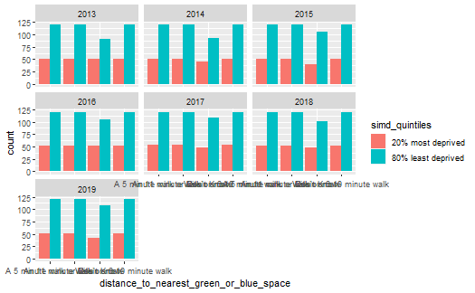

```r
#plotting simd_quintiles for every year to see if there're significant
#differences for each year
#Filtering out Simd_quintiles == "All"
green_spaces_joined %>%
  filter(simd_quintiles != "All") %>%
ggplot(aes(x = distance_to_nearest_green_or_blue_space, fill = simd_quintiles))+
  geom_bar(position = "dodge")+
  facet_wrap(~date_code)
```

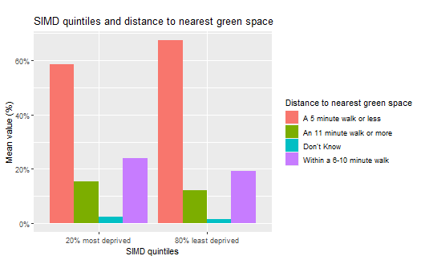

```r
#simd quinitles and distance to green spaces
green_spaces_joined %>%
  filter(simd_quintiles != "All") %>%
    group_by(simd_quintiles, distance_to_nearest_green_or_blue_space) %>%
    summarise(mean_percentage = mean(value)) %>%
  ggplot(aes(x = simd_quintiles, y = mean_percentage, fill = distance_to_nearest_green_or_blue_space))+
  geom_col(position = "dodge")+
   scale_y_continuous(labels = function(x) paste0(x*1, "%"))+
  labs(
    x = "SIMD quintiles",
    y = "Mean value (%)",
    title = "\nSIMD quintiles and distance to nearest green space",
    fill = "Distance to nearest green space"
  )
ggsave("simd.png")
```

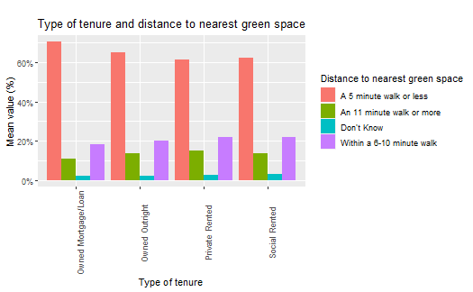

```r
#type of tenure and distance to nearest green space
green_spaces_joined %>%
 filter(type_of_tenure != "All") %>%
     group_by(type_of_tenure, distance_to_nearest_green_or_blue_space) %>%
    summarise(mean_percentage = mean(value)) %>%
  ggplot(aes(x = type_of_tenure, y = mean_percentage, fill = distance_to_nearest_green_or_blue_space))+
  geom_col(position = "dodge")+
  theme(axis.text.x = element_text(angle = 90))+
   scale_y_continuous(labels = function(x) paste0(x*1, "%"))+
  labs(
    x = "Type of tenure",
    y = "Mean value (%)",
    title = "\nType of tenure and distance to nearest green space",
    fill = "Distance to nearest green space"
  )
ggsave("tenure.png")
```

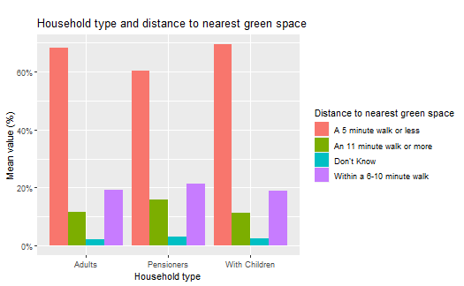

```r
#household type and distance to green spaces
green_spaces_joined %>%
  filter(household_type != "All") %>%
    group_by(household_type, distance_to_nearest_green_or_blue_space) %>%
    summarise(mean_percentage = mean(value)) %>%
  ggplot(aes(x = household_type, y = mean_percentage, fill = distance_to_nearest_green_or_blue_space))+
  geom_col(position = "dodge")+
   scale_y_continuous(labels = function(x) paste0(x*1, "%"))+
  labs(
    x = "Household type",
    y = "Mean value (%)",
    title = "\nHousehold type and distance to nearest green space",
    fill = "Distance to nearest green space"
  )
ggsave("household.png")
```

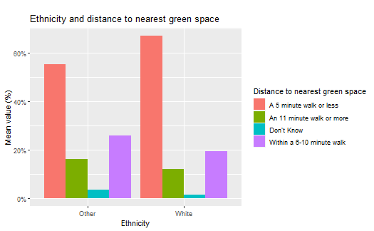

```r
#ethnicity and distance to green spaces
green_spaces_joined %>%
  filter(ethnicity != "All") %>%
    group_by(ethnicity, distance_to_nearest_green_or_blue_space) %>%
    summarise(mean_percentage = mean(value)) %>%
  ggplot(aes(x = ethnicity,
             y = mean_percentage,
             fill = distance_to_nearest_green_or_blue_space))+
  geom_col(position = "dodge")+
    scale_y_continuous(labels = function(x) paste0(x*1, "%"))+
  labs(
    x = "Ethnicity",
    y = "Mean value (%)",
    title = "\nEthnicity and distance to nearest green space",
    fill = "Distance to nearest green space"
  )
ggsave("ethnicity.png")
```

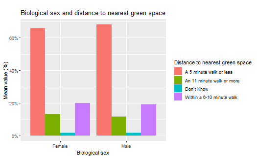

```r
#gender and distance to green spaces
green_spaces_joined %>%
 filter(gender != "All") %>%
    group_by(gender, distance_to_nearest_green_or_blue_space) %>%
    summarise(mean_percentage = mean(value)) %>%
  ggplot(aes(x = gender,
             y = mean_percentage,
             fill = distance_to_nearest_green_or_blue_space))+
  geom_col(position = "dodge")+
    scale_y_continuous(labels = function(x) paste0(x*1, "%"))+
  labs(
    x = "Biological sex",
    y = "Mean value (%)",
    title = "\nBiological sex and distance to nearest green space",
    fill = "Distance to nearest green space"
  )
ggsave("gender.png")
```

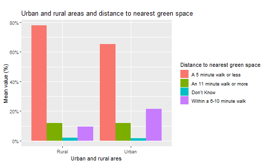

```r
#urban/ rural areas and distance to green spaces
green_spaces_joined %>%
 filter(urban_rural_classification != "All") %>%
    group_by(urban_rural_classification, distance_to_nearest_green_or_blue_space) %>%
    summarise(mean_percentage = mean(value)) %>%
  ggplot(aes(x = urban_rural_classification,
             y = mean_percentage,
             fill = distance_to_nearest_green_or_blue_space))+
  geom_col(position = "dodge")+
    scale_y_continuous(labels = function(x) paste0(x*1, "%"))+
  labs(
    x = "Urban and rural ares",
    y = "Mean value (%)",
    title = "\nUrban and rural areas and distance to nearest green space",
    fill = "Distance to nearest green space"
  )
ggsave("urban_rural.png")
```

#How do people in neighbourhoods with good access to green space differ from #those who have no good access? Are there differences how they rate their #neighbourhoods? Are there differences in how they rate their communities?

#neighbourhood

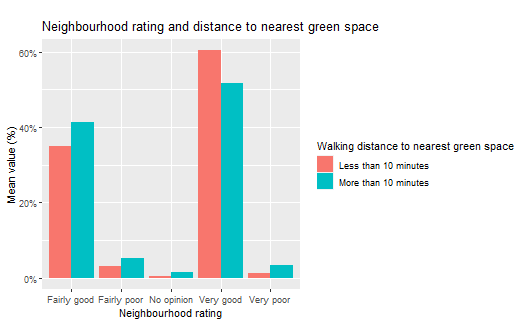

```r
#all walking distances to nearest green space
neighbourhood_rating_joined %>%
  filter(walking_distance_to_nearest_greenspace != "All") %>%
    group_by(neighbourhood_rating, walking_distance_to_nearest_greenspace) %>%
    summarise(mean_percentage = mean(value)) %>%
  ggplot(aes(x = neighbourhood_rating,
             y = mean_percentage,
             fill = walking_distance_to_nearest_greenspace))+
  geom_col(position = "dodge") +
    scale_y_continuous(labels = function(x) paste0(x*1, "%"))+
  labs(
    x = "Neighbourhood rating",
    y = "Mean value (%)",
    title = "\nNeighbourhood rating and distance to nearest green space",
    fill = "Walking distance to nearest green space"
  )
ggsave("neighbourhood_distance.png")
```

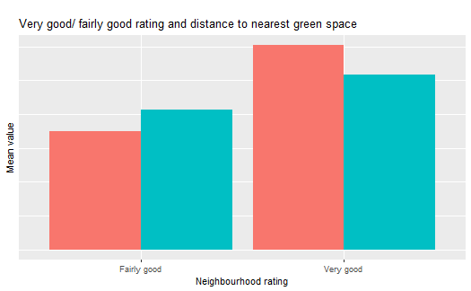

```r
#very good and fairly good rating and walking distance to green spaces
neighbourhood_rating_joined %>%
  filter(walking_distance_to_nearest_greenspace != "All",
         neighbourhood_rating == "Very good" |
         neighbourhood_rating == "Fairly good") %>%
    group_by(neighbourhood_rating, walking_distance_to_nearest_greenspace) %>%
    summarise(mean_percentage = mean(value)) %>%
  ggplot(aes(x = neighbourhood_rating,
             y = mean_percentage,
             fill = walking_distance_to_nearest_greenspace))+
  geom_col(position = "dodge")+
   theme(axis.text.y=element_blank(),
      axis.ticks.y = element_blank())+
  labs(
    x = "Neighbourhood rating",
    y = "Mean value",
    title = "\nVery good/ fairly good rating and distance to nearest green space",
    fill = "Walking distance to nearest green space"
  )+
  theme(legend.position="none")
ggsave("Very_fairly_good_neighbourhood.png")
```

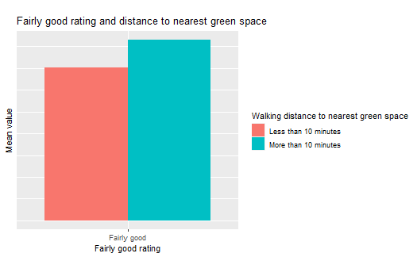

```r
#Fairly good rating and walking distance to green spaces
neighbourhood_rating_joined %>%
  filter(walking_distance_to_nearest_greenspace != "All",
         neighbourhood_rating == "Fairly good") %>%
    group_by(neighbourhood_rating, walking_distance_to_nearest_greenspace) %>%
    summarise(mean_percentage = mean(value)) %>%
  ggplot(aes(x = neighbourhood_rating,
             y = mean_percentage,
             fill = walking_distance_to_nearest_greenspace))+
  geom_col(position = "dodge")+
   theme(axis.text.y=element_blank(),
      axis.ticks.y = element_blank())+
  labs(
    x = "Fairly good rating",
    y = "Mean value",
    title = "\nFairly good rating and distance to nearest green space",
    fill = "Walking distance to nearest green space"
  )
```

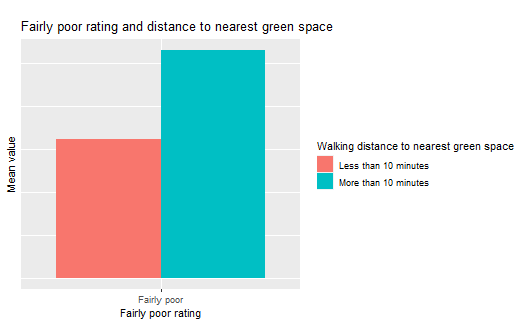

```r
#fairly poor rating and walking distance to green spaces
neighbourhood_rating_joined %>%
  filter(walking_distance_to_nearest_greenspace != "All",
         neighbourhood_rating == "Fairly poor") %>%
    group_by(neighbourhood_rating, walking_distance_to_nearest_greenspace) %>%
    summarise(mean_percentage = mean(value)) %>%
  ggplot(aes(x = neighbourhood_rating,
             y = mean_percentage,
             fill = walking_distance_to_nearest_greenspace))+
  geom_col(position = "dodge")+
   theme(axis.text.y=element_blank(),
      axis.ticks.y = element_blank())+
  labs(
    x = "Fairly poor rating",
    y = "Mean value",
    title = "\nFairly poor rating and distance to nearest green space",
    fill = "Walking distance to nearest green space"
  )
```

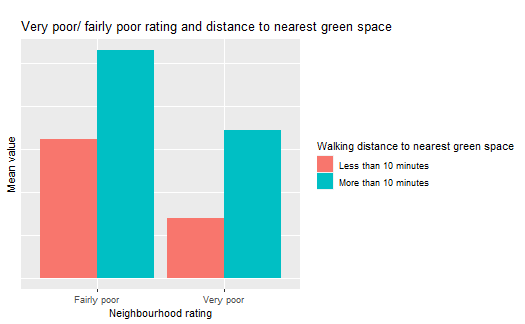

```r
#very poor rating and walking distance to green spaces
neighbourhood_rating_joined %>%
  filter(walking_distance_to_nearest_greenspace != "All",
         neighbourhood_rating == "Very poor" |
           neighbourhood_rating == "Fairly poor") %>%
    group_by(neighbourhood_rating, walking_distance_to_nearest_greenspace) %>%
    summarise(mean_percentage = mean(value)) %>%
  ggplot(aes(x = neighbourhood_rating,
             y = mean_percentage,
             fill = walking_distance_to_nearest_greenspace))+
  geom_col(position = "dodge")+
  theme(axis.text.y=element_blank(),
      axis.ticks.y = element_blank())+
  labs(
    x = "Neighbourhood rating",
    y = "Mean value",
    title = "\nVery poor/ fairly poor rating and distance to nearest green space",
    fill = "Walking distance to nearest green space"
  )
ggsave("very_fairly_poor_rating.png")
```

#community

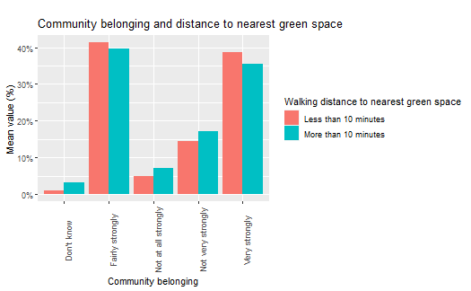

```r
#commuity belonging and walking distance to green spaces
community_belonging_joined %>%
  filter(walking_distance_to_nearest_greenspace != "All") %>%
    group_by(community_belonging, walking_distance_to_nearest_greenspace) %>%
    summarise(mean_percentage = mean(value)) %>%
  ggplot(aes(x = community_belonging,
             y = mean_percentage,
             fill = walking_distance_to_nearest_greenspace))+
  geom_col(position = "dodge")+
  theme(axis.text.x = element_text(angle = 90))+
    scale_y_continuous(labels = function(x) paste0(x*1, "%"))+
  labs(
    x = "Community belonging",
    y = "Mean value (%)",
    title = "\nCommunity belonging and distance to nearest green space",
    fill = "Walking distance to nearest green space"
  )
ggsave("community_belonging.png")
```

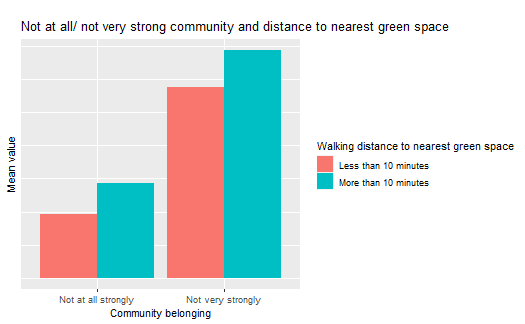

```r
#not at all/ not very strong community and walking distance to green spaces
community_belonging_joined %>%
  filter(walking_distance_to_nearest_greenspace != "All",
         community_belonging == "Not at all strongly" |
           community_belonging == "Not very strongly") %>%
    group_by(community_belonging, walking_distance_to_nearest_greenspace) %>%
    summarise(mean_percentage = mean(value)) %>%
  ggplot(aes(x = community_belonging,
             y = mean_percentage,
             fill = walking_distance_to_nearest_greenspace))+
  geom_col(position = "dodge")+
  theme(axis.text.y=element_blank(),
      axis.ticks.y = element_blank())+
  labs(
    x = "Community belonging",
    y = "Mean value",
    title = "\nNot at all/ not very strong community and distance to nearest green space",
    fill = "Walking distance to nearest green space"
  )
ggsave("not_at_all_very_community.png")
```

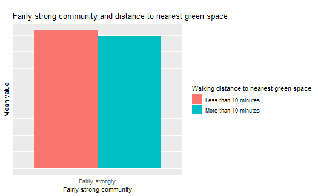

```r
#Fairly strongly community and walking distance to green spaces
community_belonging_joined %>%
  filter(walking_distance_to_nearest_greenspace != "All",
         community_belonging == "Fairly strongly") %>%
    group_by(community_belonging, walking_distance_to_nearest_greenspace) %>%
    summarise(mean_percentage = mean(value)) %>%
  ggplot(aes(x = community_belonging,
             y = mean_percentage,
             fill = walking_distance_to_nearest_greenspace))+
  geom_col(position = "dodge")+
  theme(axis.text.y=element_blank(),
      axis.ticks.y = element_blank())+
  labs(
    x = "Fairly strong community",
    y = "Mean value",
    title = "\nFairly strong community and distance to nearest green space",
    fill = "Walking distance to nearest green space"
  )
```

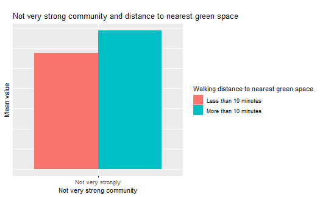

```r
#not very strong community and walking distance to green spaces
community_belonging_joined %>%
  filter(walking_distance_to_nearest_greenspace != "All",
         community_belonging == "Not very strongly") %>%
    group_by(community_belonging, walking_distance_to_nearest_greenspace) %>%
    summarise(mean_percentage = mean(value)) %>%
  ggplot(aes(x = community_belonging,
             y = mean_percentage,
             fill = walking_distance_to_nearest_greenspace))+
  geom_col(position = "dodge")+
  theme(axis.text.y=element_blank(),
      axis.ticks.y = element_blank())+
  labs(
    x = "Not very strong community",
    y = "Mean value",
    title = "\nNot very strong community and distance to nearest green space",
    fill = "Walking distance to nearest green space"
  )
```

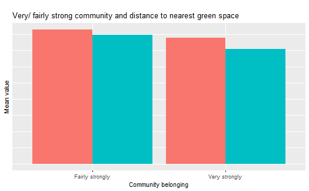

```r
#very/ fairly strong community and walking distance to green spaces
#hiding legend due to presentation space
community_belonging_joined %>%
  filter(walking_distance_to_nearest_greenspace != "All",
         community_belonging == "Very strongly"|
           community_belonging == "Fairly strongly") %>%
    group_by(community_belonging, walking_distance_to_nearest_greenspace) %>%
    summarise(mean_percentage = mean(value)) %>%
  ggplot(aes(x = community_belonging,
             y = mean_percentage,
             fill = walking_distance_to_nearest_greenspace))+
  geom_col(position = "dodge")+
  theme(axis.text.y=element_blank(),
      axis.ticks.y = element_blank())+
  labs(
    x = "Community belonging",
    y = "Mean value",
    title = "\nVery/ fairly strong community and distance to nearest green space",
    fill = "Walking distance to nearest green space"
  )+
  theme(legend.position="none")
ggsave("very_fairly_strong_community.png")
```

##interestngly we can say that communities with higher community belonging are #closer to a green space. There is probably a correlation between community #rating and neighbourhood rating

#time series ~ HOW DOES GREEN SPACE ACCESS CHANGE OVER TIME?

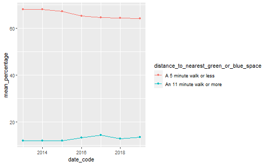

```r
#5 minute and 11 minute or more walk over time
green_spaces_joined %>%
  filter(distance_to_nearest_green_or_blue_space == "A 5 minute walk or less" |
           distance_to_nearest_green_or_blue_space == "An 11 minute walk or more") %>%
    group_by(date_code, distance_to_nearest_green_or_blue_space) %>%
    summarise(mean_percentage = mean(value)) %>%
  ggplot(aes(x = date_code,
             y = mean_percentage,
             colour = distance_to_nearest_green_or_blue_space))+
   geom_point()+
  geom_line()
```

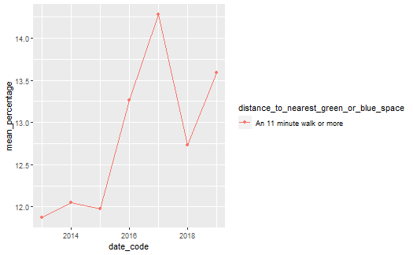

```r
#11 minute walk over time
green_spaces_joined %>%
  filter(distance_to_nearest_green_or_blue_space == "An 11 minute walk or more") %>%
    group_by(date_code, distance_to_nearest_green_or_blue_space) %>%
    summarise(mean_percentage = mean(value)) %>%
  ggplot(aes(x = date_code,
             y = mean_percentage,
             colour = distance_to_nearest_green_or_blue_space))+
   geom_point()+
  geom_line()
```

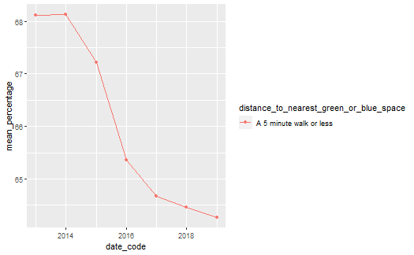

```r
#5 minute walk over time
green_spaces_joined %>%
  filter(distance_to_nearest_green_or_blue_space == "A 5 minute walk or less") %>%
    group_by(date_code, distance_to_nearest_green_or_blue_space) %>%
    summarise(mean_percentage = mean(value)) %>%
  ggplot(aes(x = date_code,
             y = mean_percentage,
             colour = distance_to_nearest_green_or_blue_space))+
   geom_point()+
  geom_line()
```

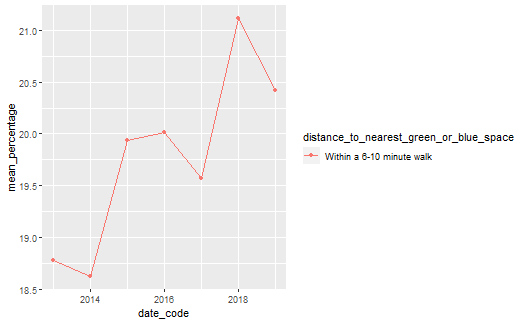

```r
#6-10 minute walk over time
green_spaces_joined %>%
  filter(distance_to_nearest_green_or_blue_space == "Within a 6-10 minute walk") %>%
    group_by(date_code, distance_to_nearest_green_or_blue_space) %>%
    summarise(mean_percentage = mean(value)) %>%
  ggplot(aes(x = date_code,
             y = mean_percentage,
             colour = distance_to_nearest_green_or_blue_space))+
   geom_point()+
  geom_line()
```

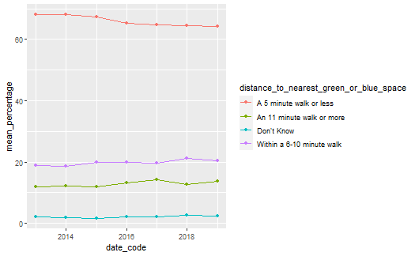

```r
#All walks over time excluding "All"
green_spaces_joined %>%
  filter(distance_to_nearest_green_or_blue_space != "All") %>%
    group_by(date_code, distance_to_nearest_green_or_blue_space) %>%
    summarise(mean_percentage = mean(value)) %>%
  ggplot(aes(x = date_code,
             y = mean_percentage,
             colour = distance_to_nearest_green_or_blue_space))+
  geom_point()+
  geom_line()
```

```r
#aggregate response data
aggregate_responses <- read_csv("../raw_data/shs_aggregate_responses (1).csv")
```

```r
apply(aggregate_responses, 2, anyNA)
```

```
                                 year                   community_belonging                  neighbourhood_rating
                                FALSE                                 FALSE                                 FALSE
      distance_to_nearest_green_space satisfaction_with_nearest_green_space                                   age
                                FALSE                                  TRUE                                 FALSE
                               gender                       economic_status                        household_size
                                FALSE                                  TRUE                                 FALSE
              highest_education_level               nearest_green_space_use       volunteering_last_twelve_months
                                 TRUE                                  TRUE                                  TRUE
                            n_persons
                                FALSE
```

#Ok I have decided to leave the Na values as they are. I’m not sure if imputing them would change the results of my analysis that much. Or at least the analysis wouldn’t contain the original data.

```r
#creating dummy variables for logistic regression analysis
aggregate_responses_dummies <- aggregate_responses %>%
  select(community_belonging, neighbourhood_rating, distance_to_nearest_green_space, satisfaction_with_nearest_green_space,
         age, gender, economic_status, household_size, highest_education_level) %>%
fastDummies::dummy_cols(select_columns = "neighbourhood_rating", remove_first_dummy = TRUE, remove_selected_columns = TRUE) %>%
  fastDummies::dummy_cols(select_columns = "community_belonging", remove_first_dummy = TRUE, remove_selected_columns = TRUE) %>% fastDummies::dummy_cols(select_columns = "distance_to_nearest_green_space", remove_first_dummy = TRUE, remove_selected_columns = TRUE) %>%
  fastDummies::dummy_cols(select_columns = "satisfaction_with_nearest_green_space", remove_first_dummy = TRUE, remove_selected_columns = TRUE) %>%
  fastDummies::dummy_cols(select_columns = "age", remove_first_dummy = TRUE, remove_selected_columns = TRUE) %>%
  fastDummies::dummy_cols(select_columns = "gender", remove_first_dummy = TRUE, remove_selected_columns = TRUE) %>%
  fastDummies::dummy_cols(select_columns = "economic_status", remove_first_dummy = TRUE, remove_selected_columns = TRUE) %>%
  fastDummies::dummy_cols(select_columns = "highest_education_level", remove_first_dummy = TRUE, remove_selected_columns = TRUE)
#using clean names
aggregate_responses_dummies <- aggregate_responses_dummies %>%
  clean_names()
```

#The ideal model for this type of data would be a logistic regression model as I have a dichotomous variables (1, 0)

#After playing a bit with the model and the data, this is the best model as I have a lower AIC (47265)

```r
model5c <- glm(formula = neighbourhood_rating_very_good ~ community_belonging_very_strongly+
                satisfaction_with_nearest_green_space_very_satisfied+
                highest_education_level_standard_grade_or_equiv_svq_level_1_or_2+
                community_belonging_fairly_strongly,
              data = aggregate_responses_dummies, family = binomial(link = "logit"))

summary(model5c)
```

```
Call:
glm(formula = neighbourhood_rating_very_good ~ community_belonging_very_strongly +
    satisfaction_with_nearest_green_space_very_satisfied + highest_education_level_standard_grade_or_equiv_svq_level_1_or_2 +
    community_belonging_fairly_strongly, family = binomial(link = "logit"),
    data = aggregate_responses_dummies)

Deviance Residuals:
    Min       1Q   Median       3Q      Max
-2.0083  -1.1302   0.5345   0.9245   1.7810

Coefficients:
                                                                 Estimate Std. Error z value Pr(>|z|)
(Intercept)                                                      -0.95419    0.02467  -38.69   <2e-16 ***
community_belonging_very_strongly                                 1.98581    0.03100   64.06   <2e-16 ***
satisfaction_with_nearest_green_space_very_satisfied              0.84208    0.02401   35.07   <2e-16 ***
highest_education_level_standard_grade_or_equiv_svq_level_1_or_2 -0.40262    0.02565  -15.70   <2e-16 ***
community_belonging_fairly_strongly                               0.90574    0.02761   32.81   <2e-16 ***
---
Signif. codes:  0 ‘***’ 0.001 ‘**’ 0.01 ‘*’ 0.05 ‘.’ 0.1 ‘ ’ 1

(Dispersion parameter for binomial family taken to be 1)

    Null deviance: 53901  on 39270  degrees of freedom
Residual deviance: 47255  on 39266  degrees of freedom
  (19259 observations deleted due to missingness)
AIC: 47265

Number of Fisher Scoring iterations: 4
```

```r
model6c <- glm(formula = neighbourhood_rating_very_good ~ community_belonging_not_very_strongly+
                 satisfaction_with_nearest_green_space_very_satisfied+
                 highest_education_level_standard_grade_or_equiv_svq_level_1_or_2+
                 community_belonging_fairly_strongly,
              data = aggregate_responses_dummies, family = binomial(link = "logit"))

summary(model6c)
```

```
Call:
glm(formula = neighbourhood_rating_very_good ~ community_belonging_not_very_strongly +
    satisfaction_with_nearest_green_space_very_satisfied + highest_education_level_standard_grade_or_equiv_svq_level_1_or_2 +
    community_belonging_fairly_strongly, family = binomial(link = "logit"),
    data = aggregate_responses_dummies)

Deviance Residuals:
    Min       1Q   Median       3Q      Max
-1.8183  -1.1527   0.6520   0.9463   1.7383

Coefficients:
                                                                 Estimate Std. Error z value Pr(>|z|)
(Intercept)                                                       0.57131    0.02036   28.06   <2e-16 ***
community_belonging_not_very_strongly                            -1.43923    0.03157  -45.58   <2e-16 ***
satisfaction_with_nearest_green_space_very_satisfied              0.86928    0.02327   37.36   <2e-16 ***
highest_education_level_standard_grade_or_equiv_svq_level_1_or_2 -0.39360    0.02478  -15.88   <2e-16 ***
community_belonging_fairly_strongly                              -0.62972    0.02369  -26.59   <2e-16 ***
---
Signif. codes:  0 ‘***’ 0.001 ‘**’ 0.01 ‘*’ 0.05 ‘.’ 0.1 ‘ ’ 1

(Dispersion parameter for binomial family taken to be 1)

    Null deviance: 53901  on 39270  degrees of freedom
Residual deviance: 49625  on 39266  degrees of freedom
  (19259 observations deleted due to missingness)
AIC: 49635

Number of Fisher Scoring iterations: 4
```

```r
#trying anova to test which of the two models fits the data better
anova(model5c, model6c, test = "Chisq")
```

```
Analysis of Deviance Table

Model 1: neighbourhood_rating_very_good ~ community_belonging_very_strongly +
    satisfaction_with_nearest_green_space_very_satisfied + highest_education_level_standard_grade_or_equiv_svq_level_1_or_2 +
    community_belonging_fairly_strongly
Model 2: neighbourhood_rating_very_good ~ community_belonging_not_very_strongly +
    satisfaction_with_nearest_green_space_very_satisfied + highest_education_level_standard_grade_or_equiv_svq_level_1_or_2 +
    community_belonging_fairly_strongly
  Resid. Df Resid. Dev Df Deviance Pr(>Chi)
1     39266      47255
2     39266      49625  0  -2369.8
```

#After playing a bit with the model and the data, this is the best model, model5c is the best model as I have a lower AIC (47265)

```r
#adding predicted probabilities
library(modelr)
neighbourhood_rating_4_pred <- aggregate_responses_dummies %>%
  add_predictions(model5c, type = "response")
neighbourhood_rating_4_pred
```

| household_size | neighbourhood_rating_fairly_poor | neighbourhood_rating_no_opinion | neighbourhood_rating_very_good | neighbourhood_rating_very_poor | community_belonging_fairly_strongly | community_belonging_not_at_all_strongly | community_belonging_not_very_strongly | community_belonging_very_strongly | distance_to_nearest_green_space_dont_know | distance_to_nearest_green_space_more_than_a_30_minute_walk_away | distance_to_nearest_green_space_within_a_6_10_minute_walk | distance_to_nearest_green_space_within_a_21_30_minute_walk | distance_to_nearest_green_space_within_an_11_20_minute_walk | satisfaction_with_nearest_green_space_fairly_satisfied | satisfaction_with_nearest_green_space_neither_satisfied_nor_dissatisfied | satisfaction_with_nearest_green_space_no_opinion | satisfaction_with_nearest_green_space_very_dissatisfied | satisfaction_with_nearest_green_space_very_satisfied | satisfaction_with_nearest_green_space_na | age_35_64_years | age_65_years | gender_male | economic_status_other | economic_status_part_time_employment | economic_status_retired | economic_status_self_employed | economic_status_training | economic_status_na | highest_education_level_higher_a_level_or_equivalent_svq_level_3 | … |
| --- | --- | --- | --- | --- | --- | --- | --- | --- | --- | --- | --- | --- | --- | --- | --- | --- | --- | --- | --- | --- | --- | --- | --- | --- | --- | --- | --- | --- | --- | --- |
| 3 | 0 | 0 | 0 | 0 | 0 | 0 | 0 | 0 | 0 | 0 | 0 | 0 | 0 | 0 | 0 | 0 | 0 | 0 | 0 | 1 | 0 | 0 | 0 | 0 | 0 | 0 | 0 | 0 | 0 | … |
| 1 | 0 | 0 | 0 | 0 | 0 | 0 | 0 | 0 | 0 | 0 | 0 | 0 | 0 | 1 | 0 | 0 | 0 | 0 | 0 | 0 | 0 | 0 | 0 | 0 | 0 | 0 | 0 | 0 | 0 | … |
| 2 | 0 | 0 | 0 | 0 | 0 | 0 | 0 | 0 | 0 | 0 | 0 | 0 | 0 | 1 | 0 | 0 | 0 | 0 | 0 | 0 | 0 | 0 | 0 | 0 | 0 | 0 | 0 | 0 | 0 | … |
| 2 | 0 | 0 | 0 | 0 | 0 | 0 | 0 | 0 | 0 | 0 | 0 | 0 | 0 | 1 | 0 | 0 | 0 | 0 | 0 | 0 | 0 | 0 | 0 | 1 | 0 | 0 | 0 | 0 | NA | … |
| 2 | 0 | 0 | 0 | 0 | 0 | 0 | 0 | 0 | 0 | 0 | 0 | 0 | 0 | 1 | 0 | 0 | 0 | 0 | 0 | 0 | 0 | 1 | 0 | 1 | 0 | 0 | 0 | 0 | 0 | … |
| 1 | 0 | 0 | 0 | 0 | 0 | 0 | 0 | 0 | 0 | 0 | 0 | 0 | 0 | 1 | 0 | 0 | 0 | 0 | 0 | 0 | 0 | 1 | 0 | 0 | 0 | 0 | 1 | 0 | 0 | … |
| 2 | 0 | 0 | 0 | 0 | 0 | 0 | 0 | 0 | 0 | 0 | 0 | 0 | 0 | 1 | 0 | 0 | 0 | 0 | 0 | 0 | 0 | 1 | 0 | 0 | 0 | 0 | 1 | 0 | 0 | … |
| 1 | 0 | 0 | 0 | 0 | 0 | 0 | 0 | 0 | 0 | 0 | 0 | 0 | 0 | 1 | 0 | 0 | 0 | 0 | 0 | 1 | 0 | 0 | 1 | 0 | 0 | 0 | 0 | 0 | 0 | … |
| 1 | 0 | 0 | 0 | 0 | 0 | 0 | 0 | 0 | 0 | 0 | 0 | 0 | 0 | 1 | 0 | 0 | 0 | 0 | 0 | 1 | 0 | 1 | 0 | 0 | 0 | 0 | 0 | 0 | NA | … |
| 1 | 0 | 0 | 0 | 0 | 0 | 0 | 0 | 0 | 0 | 0 | 0 | 0 | 0 | 1 | 0 | 0 | 0 | 0 | 0 | 1 | 0 | 1 | 1 | 0 | 0 | 0 | 0 | 0 | NA | … |

[output cut: 990 more lines]

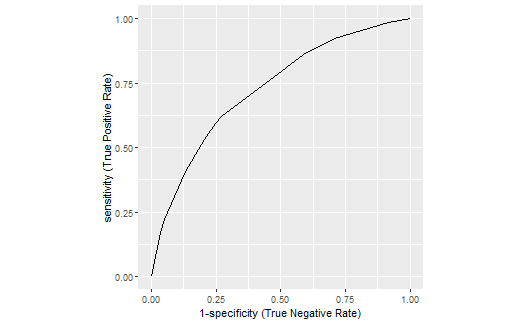

```r
library(pROC)
roc_obj_4_pred <- neighbourhood_rating_4_pred %>%
  roc(response = neighbourhood_rating_very_good, predictor = pred)
roc_curve <- ggroc(data = roc_obj_4_pred, legacy.axes = TRUE)+
  coord_fixed()+
  ylab("sensitivity (True Positive Rate)")+
  xlab("1-specificity (True Negative Rate)")

roc_curve
```

```r
#calculating the area under the curve
auc(roc_obj_4_pred)
```

```
Area under the curve: 0.7282
```

#Area under the curve of 0.7282. This makes our prediction as “good”.